# Homework_7

Alexander Kissonergis

2024-03-06

Here I will be creating a data set that might mimic the hormetic effects we see after an insect has had exposure to pesticide. We should see a dramatic difference in cell count response, with the treatment showing a higher cell count. The numbers are highly dependent on the methods used, so in this case, I am using numbers that are arbitrarily matching patterns.

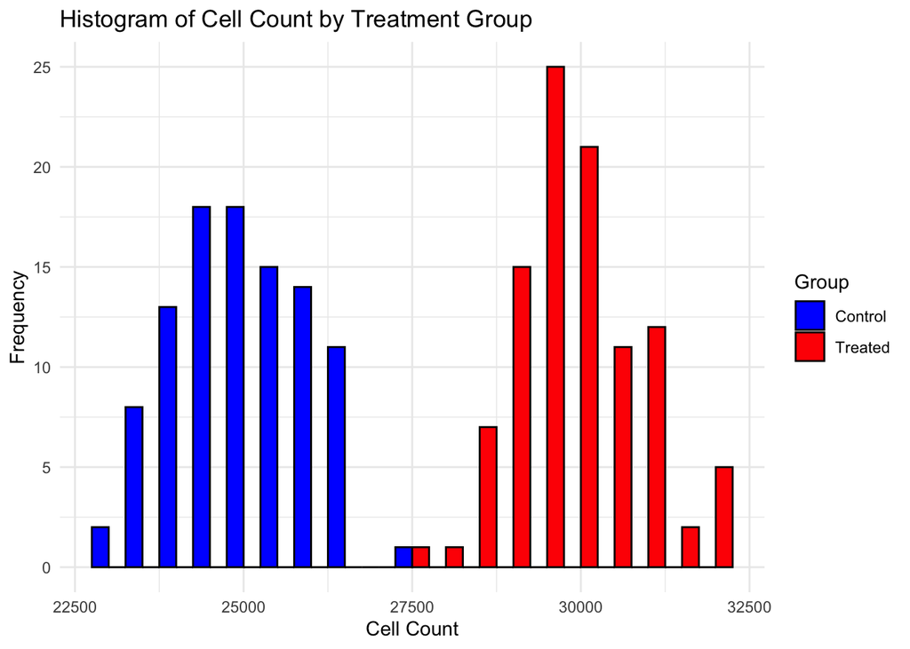

```r
#loading in ggplot
library(ggplot2)

#setting a seed for reproducible data
set.seed(190)

# creating my treatment groups, here I am using SD to define the range instead of what we did in class
control <- rnorm(100, mean = 25000, sd = 1000)
treated <- rnorm(100, mean = 30000, sd = 1000)

# Create sample IDs
sample_ids <- paste(1:200)

#  creating a dataframe named z in the spirit of continuing the classes methods, I am using a
z <- data.frame(
  Sample_ID = sample_ids,
  Group = rep(c("Control", "Treated"), each = 100),
  Cell_Count = c(control, treated)
)

# the creation of the histogram from last class is a bit confusing so using this method from ggplot instead
OG_plot <- ggplot(z, aes(x = Cell_Count, fill = Group)) +
  geom_histogram(binwidth = 500, position = "dodge", color = "black") +
  labs(title = "Histogram of Cell Count by Treatment Group",
       x = "Cell Count", y = "Frequency") +
  scale_fill_manual(values = c("Control" = "blue", "Treated" = "red")) +
  theme_minimal()

print(OG_plot)
```

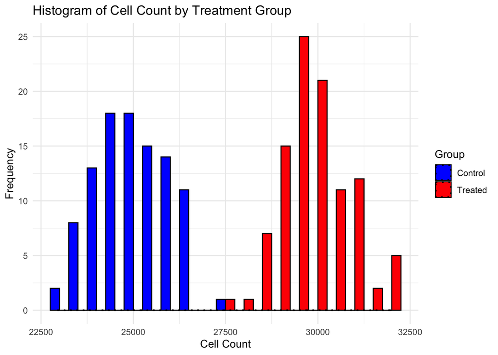

```r
#adding a geom den curve, however, this doesn't seem to be following the trend, perhaps since the two treatments are so different?

OG_plot <-  OG_plot +  geom_density(linetype="dotted",size=0.75)
print(OG_plot)
```

Since I am just trying to compare the mean cell counts between the two treatments, I will use an ANOVA

```r
#running an anova

anova <- aov(Cell_Count ~ Group, data = z)
summary(anova)
```

```
##              Df    Sum Sq   Mean Sq F value Pr(>F)
## Group         1 1.194e+09 1.194e+09    1393 <2e-16 ***
## Residuals   198 1.698e+08 8.574e+05
## ---
## Signif. codes:  0 '***' 0.001 '**' 0.01 '*' 0.05 '.' 0.1 ' ' 1
```

Testing out different means and retesting anova

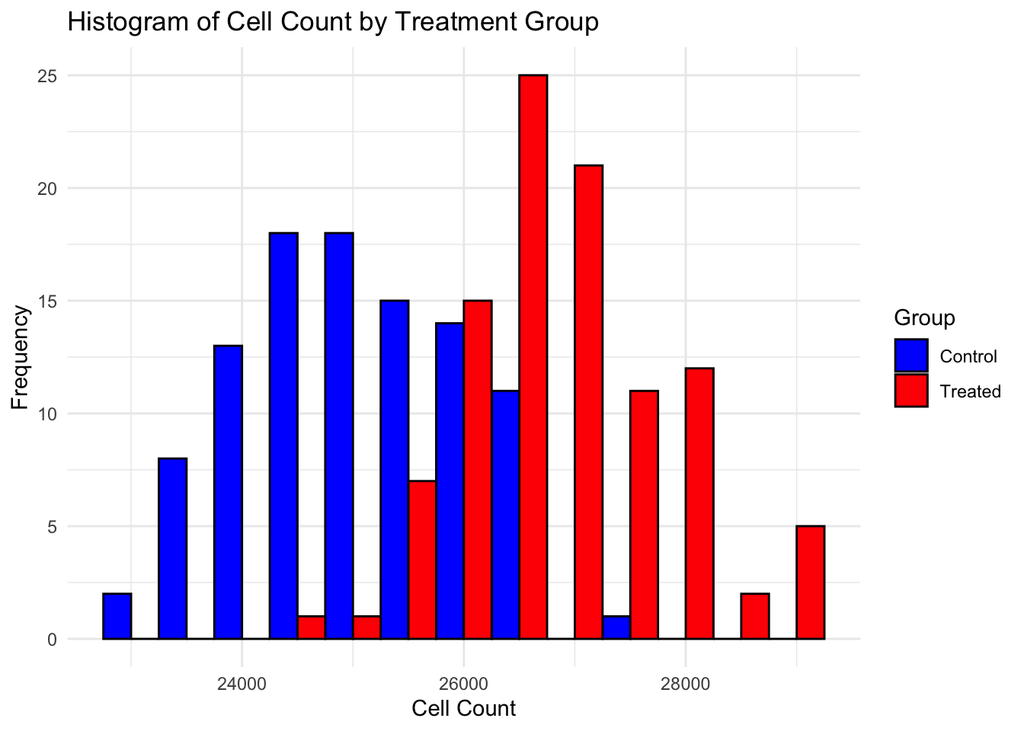

```r
#testing out different means

#setting a seed for reproducible data
set.seed(190)

# creating my treatment groups, here I am using SD to define the range instead of what we did in class
control <- rnorm(100, mean = 25000, sd = 1000)
treated <- rnorm(100, mean = 27000, sd = 1000)

# Create sample IDs
sample_ids <- paste(1:200)

#  creating a dataframe named z in the spirit of continuing the classes methods, I am using a
z2 <- data.frame(
  Sample_ID = sample_ids,
  Group = rep(c("Control", "Treated"), each = 100),
  Cell_Count = c(control, treated)
)

# the creation of the histogram from last class is a bit confusing so using this method from ggplot instead
OG_plot2 <- ggplot(z2, aes(x = Cell_Count, fill = Group)) +
  geom_histogram(binwidth = 500, position = "dodge", color = "black") +
  labs(title = "Histogram of Cell Count by Treatment Group",
       x = "Cell Count", y = "Frequency") +
  scale_fill_manual(values = c("Control" = "blue", "Treated" = "red")) +
  theme_minimal()

print(OG_plot2)
```

```r
anova2 <- aov(Cell_Count ~ Group, data = z2)
```

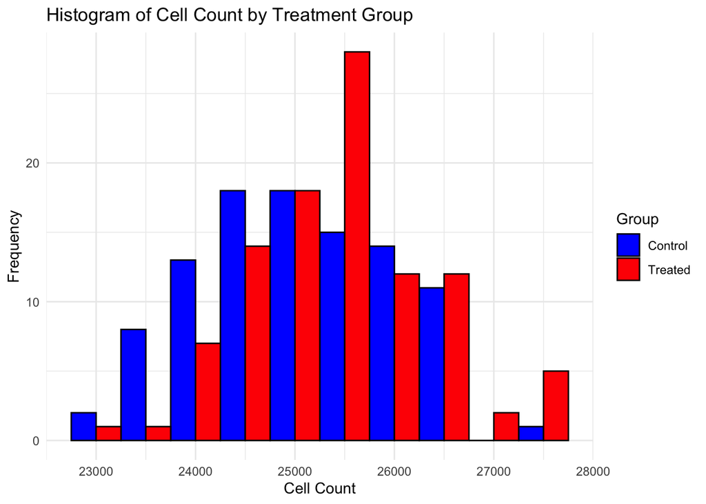

```r
#setting a seed for reproducible data
set.seed(190)

# creating my treatment groups, here I am using SD to define the range instead of what we did in class
control <- rnorm(100, mean = 25000, sd = 1000)
treated <- rnorm(100, mean = 25555, sd = 1000)

# Create sample IDs
sample_ids <- paste(1:200)

#  creating a dataframe named z in the spirit of continuing the classes methods, I am using a
z3 <- data.frame(
  Sample_ID = sample_ids,
  Group = rep(c("Control", "Treated"), each = 100),
  Cell_Count = c(control, treated)
)

# the creation of the histogram from last class is a bit confusing so using this method from ggplot instead
OG_plot3 <- ggplot(z3, aes(x = Cell_Count, fill = Group)) +
  geom_histogram(binwidth = 500, position = "dodge", color = "black") +
  labs(title = "Histogram of Cell Count by Treatment Group",
       x = "Cell Count", y = "Frequency") +
  scale_fill_manual(values = c("Control" = "blue", "Treated" = "red")) +
  theme_minimal()

print(OG_plot3)
```

```r
anova3 <- aov(Cell_Count ~ Group, data = z3)
summary(anova3)
```

```
##              Df    Sum Sq Mean Sq F value   Pr(>F)
## Group         1   9767623 9767623   11.39 0.000888 ***
## Residuals   198 169765592  857402
## ---
## Signif. codes:  0 '***' 0.001 '**' 0.01 '*' 0.05 '.' 0.1 ' ' 1
```

It’s STILL significant, and hasn’t changed in the degree. I will try again. Ok, the results are no longer significant, I will move back upwards in the mean.

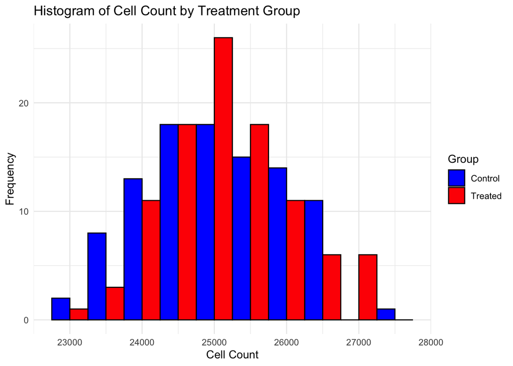

```r
#setting a seed for reproducible data
set.seed(190)

# creating my treatment groups, here I am using SD to define the range instead of what we did in class
control <- rnorm(100, mean = 25000, sd = 1000)
treated <- rnorm(100, mean = 25250, sd = 1000)

# Create sample IDs
sample_ids <- paste(1:200)

#  creating a dataframe named z in the spirit of continuing the classes methods, I am using a
z4 <- data.frame(
  Sample_ID = sample_ids,
  Group = rep(c("Control", "Treated"), each = 100),
  Cell_Count = c(control, treated)
)

# the creation of the histogram from last class is a bit confusing so using this method from ggplot instead
OG_plot4 <- ggplot(z4, aes(x = Cell_Count, fill = Group)) +
  geom_histogram(binwidth = 500, position = "dodge", color = "black") +
  labs(title = "Histogram of Cell Count by Treatment Group",
       x = "Cell Count", y = "Frequency") +
  scale_fill_manual(values = c("Control" = "blue", "Treated" = "red")) +
  theme_minimal()

print(OG_plot4)
```

```r
anova4 <- aov(Cell_Count ~ Group, data = z4)
summary(anova4)
```

```
##              Df    Sum Sq Mean Sq F value Pr(>F)
## Group         1    938271  938271   1.094  0.297
## Residuals   198 169765592  857402
```

It looks like right around 25450 (probably a bit before) is where we start to get a significant difference (one asterisk on the output, p = 0.0108 *). So it seems we can get around a mean difference of 450 cells for the effects size.

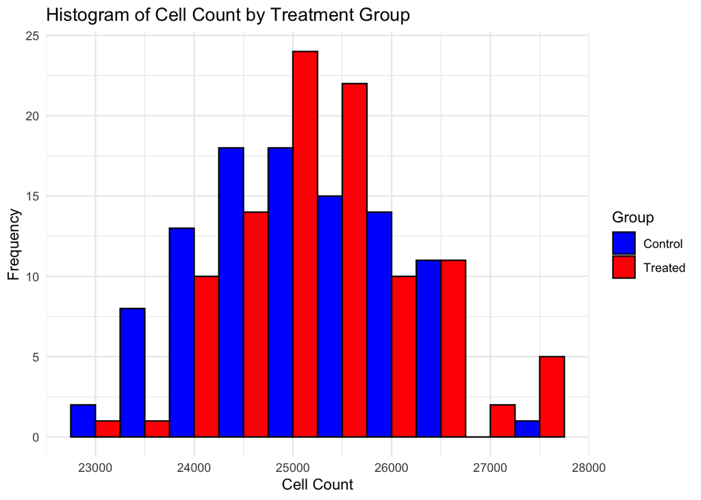

```r
#setting a seed for reproducible data
set.seed(190)

# creating my treatment groups, here I am using SD to define the range instead of what we did in class
control <- rnorm(100, mean = 25000, sd = 1000)
treated <- rnorm(100, mean = 25450, sd = 1000)

# Create sample IDs
sample_ids <- paste(1:200)

#  creating a dataframe named z in the spirit of continuing the classes methods, I am using a
z5 <- data.frame(
  Sample_ID = sample_ids,
  Group = rep(c("Control", "Treated"), each = 100),
  Cell_Count = c(control, treated)
)

# the creation of the histogram from last class is a bit confusing so using this method from ggplot instead
OG_plot5 <- ggplot(z5, aes(x = Cell_Count, fill = Group)) +
  geom_histogram(binwidth = 500, position = "dodge", color = "black") +
  labs(title = "Histogram of Cell Count by Treatment Group",
       x = "Cell Count", y = "Frequency") +
  scale_fill_manual(values = c("Control" = "blue", "Treated" = "red")) +
  theme_minimal()

print(OG_plot5)
```

```r
anova5 <- aov(Cell_Count ~ Group, data = z5)
summary(anova5)
```

```
##              Df    Sum Sq Mean Sq F value Pr(>F)
## Group         1   5678010 5678010   6.622 0.0108 *
## Residuals   198 169765592  857402
## ---
## Signif. codes:  0 '***' 0.001 '**' 0.01 '*' 0.05 '.' 0.1 ' ' 1
```

ok now I will be getting rid of the seed just to test for a bit of random variation per the hw instructions. These results were extremely significant. Much different result than the last time.

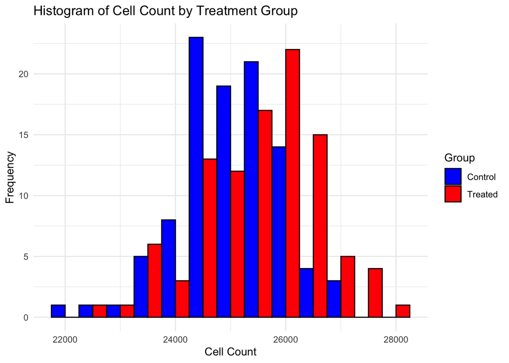

```r
# creating my treatment groups, here I am using SD to define the range instead of what we did in class
control <- rnorm(100, mean = 25000, sd = 1000)
treated <- rnorm(100, mean = 25450, sd = 1000)

# Create sample IDs
sample_ids <- paste(1:200)

#  creating a dataframe named z in the spirit of continuing the classes methods, I am using a
zRANDOM <- data.frame(
  Sample_ID = sample_ids,
  Group = rep(c("Control", "Treated"), each = 100),
  Cell_Count = c(control, treated)
)

# the creation of the histogram from last class is a bit confusing so using this method from ggplot instead
OG_plot_RANDOM <- ggplot(zRANDOM, aes(x = Cell_Count, fill = Group)) +
  geom_histogram(binwidth = 500, position = "dodge", color = "black") +
  labs(title = "Histogram of Cell Count by Treatment Group",
       x = "Cell Count", y = "Frequency") +
  scale_fill_manual(values = c("Control" = "blue", "Treated" = "red")) +
  theme_minimal()

print(OG_plot_RANDOM)
```

```r
anova_RANDOM <- aov(Cell_Count ~ Group, data = zRANDOM)
summary(anova_RANDOM)
```

```
##              Df    Sum Sq  Mean Sq F value  Pr(>F)
## Group         1  12568840 12568840   12.74 0.00045 ***
## Residuals   198 195377231   986754
## ---
## Signif. codes:  0 '***' 0.001 '**' 0.01 '*' 0.05 '.' 0.1 ' ' 1
```

Trying again. And again very significant. It seems there is a wide variety of potential effect size. Running it a third time and the result was no longer significant. A fourth times showed no significance as well. A fifth time was very significant.

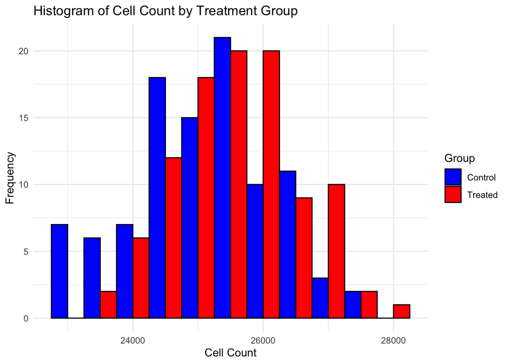

```r
# creating my treatment groups, here I am using SD to define the range instead of what we did in class
control <- rnorm(100, mean = 25000, sd = 1000)
treated <- rnorm(100, mean = 25450, sd = 1000)

# Create sample IDs
sample_ids <- paste(1:200)

#  creating a dataframe named z in the spirit of continuing the classes methods, I am using a
zRANDOM <- data.frame(
  Sample_ID = sample_ids,
  Group = rep(c("Control", "Treated"), each = 100),
  Cell_Count = c(control, treated)
)

# the creation of the histogram from last class is a bit confusing so using this method from ggplot instead
OG_plot_RANDOM <- ggplot(zRANDOM, aes(x = Cell_Count, fill = Group)) +
  geom_histogram(binwidth = 500, position = "dodge", color = "black") +
  labs(title = "Histogram of Cell Count by Treatment Group",
       x = "Cell Count", y = "Frequency") +
  scale_fill_manual(values = c("Control" = "blue", "Treated" = "red")) +
  theme_minimal()

print(OG_plot_RANDOM)
```

```r
anova_RANDOM <- aov(Cell_Count ~ Group, data = zRANDOM)
summary(anova_RANDOM)
```

```
##              Df    Sum Sq  Mean Sq F value   Pr(>F)
## Group         1  12296196 12296196   12.47 0.000514 ***
## Residuals   198 195218460   985952
## ---
## Signif. codes:  0 '***' 0.001 '**' 0.01 '*' 0.05 '.' 0.1 ' ' 1
```